# Séries Temporelles et Analyse Economique

Pascal Lavergne

```r
library(zoo)
library(xts)
library(urca)
library(Quandl)
library(astsa)
library(kableExtra)
library(xtable)
library(cointReg)
library(dynlm)
Quandl.api_key("9EPWVxYmnNgknQvXGXx8")
```

# Exercice 1 : Modèle sur la consommation et le revenu

## Faire une régression de log(cons) sur log(inc). La régression est-elle fallacieuse ?

On sait qu’opérer une regression sur des séries temporelles non stationnaires peut mener à une regression falacieuse. Ces regressions falacieuses peuvent apparaître comme donnant des predictions assez justes dans le court terme mais seront dans la majorité des cas inefficaces pour produire des prédictions exactes dans le long terme. Plusieurs signes peuvent indiquer ce genre de regression, notamment un R2 particulièrement élevé ainsi qu’une forte autocorrélation des résidus.

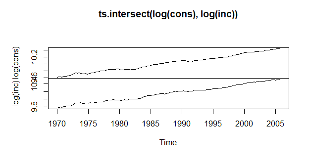

```r
cons <- Quandl("FRED/A794RX0Q048SBEA",
start_date="1970-01-01",
end_date="2005-12-31",
type="ts")
inc <- Quandl("FRED/A229RX0Q048SBEA",
start_date="1970-01-01",
end_date="2005-12-31",
type="ts")
plot(ts.intersect(log(cons),log(inc)))
```

En effet, on voit sur la figure 1 ci-dessus qu’aucune de nos deux séries n’est stationnaires, mais comportent bien une tendances similaire claire à la hausse.

```r
model1 <- lm(log(cons)~log(inc))
summary(model1)
```

```
##
## Call:
## lm(formula = log(cons) ~ log(inc))
##
## Residuals:
##       Min        1Q    Median        3Q       Max
## -0.035409 -0.006072  0.000003  0.006910  0.025089
##
## Coefficients:
##              Estimate Std. Error t value Pr(>|t|)
## (Intercept) -1.338099   0.044752   -29.9   <2e-16 ***
## log(inc)     1.119100   0.004408   253.9   <2e-16 ***
## ---
## Signif. codes:  0 '***' 0.001 '**' 0.01 '*' 0.05 '.' 0.1 ' ' 1
##
## Residual standard error: 0.01114 on 142 degrees of freedom
## Multiple R-squared:  0.9978, Adjusted R-squared:  0.9978
## F-statistic: 6.445e+04 on 1 and 142 DF,  p-value: < 2.2e-16
```

On peut alors vérifier que nos résidus ont également une tendance stochastique, appuyant l’idée d’une régression falacieuse ou bien à l’inverse voir que nos résidus sont stationnaires ce qui irait alors dans le sens d’une regression non-falacieuse.

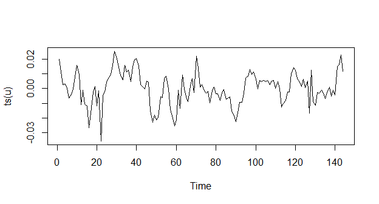

```r
u <- residuals(model1)
plot(ts(u))
```

```r
aux <- acf2(u)
```

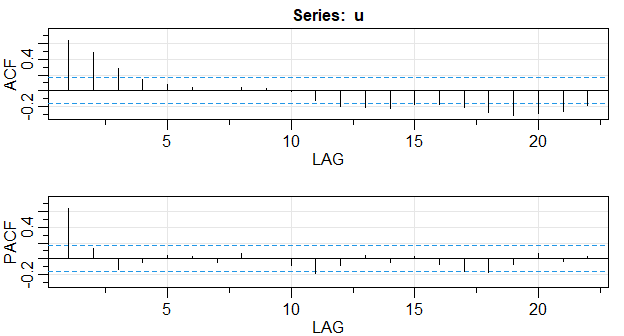

## Appliquez la procédure d’Engle et Granger à l’équation reliant consommation et revenu

Pour s’assurer de la stationnarité de nos erreurs, un test formel peut être implémenté, la Procédure de Engle et Grangerle utilisant notamment le “Augmented-Dickey-Fuller Unit Root Test”.

```r
adf.u <- ur.df(u, type="drift", selectlags = "BIC", lags = 15)
res.df <- data.frame(as.vector(adf.u@teststat), adf.u@cval)
names(res.df) <- c('Stat', "CV 1pct", "CV 5pct", "CV 10pct")
xtable(res.df) %>%
  kable(digits=2) %>%
        kable_styling()
```

|  | Stat | CV 1pct | CV 5pct | CV 10pct |
| --- | --- | --- | --- | --- |
| tau2 | -4.04 | -3.46 | -2.88 | -2.57 |
| phi1 | 8.31 | 6.52 | 4.63 | 3.81 |

On voit sur le tableau ci-dessus que notre Statistique de Test est inférieur à notre valeur critique à 1% : -4,05 < -3,46 On rejetterait donc au seuil de 1 pourcent,et on pourrait alors conclure qu’il n’y a de pas de racine unitaire et que nos résidus sont donc stationnaires.  
Cependant, la valeur critique asymptotique du test de racine unitaire doit être corrigée pour prendre en compte que les résidus ont été estimés, ce n’est pas une valeure formelle. En effet, *u* a été estimé, **c’est le résidu d’une régression estimée**

Il faut en réalité la comparer avec la table de valeur suivante

| l | cv1percent | cv5percent | cv10percent |
| --- | --- | --- | --- |
| 2 | -3.90 | -3.34 | -3.04 |
| 3 | -4.29 | -3.74 | -3.45 |
| 4 | -4.64 | -4.10 | -3.81 |
| 5 | -4.96 | -4.42 | -4.13 |

En prenant les valeurs critiques correspondant à l = 2 (le nombre de variables considérées), on conclut qu’il n’y a pas de tendance stochastique dans la série des résidus.

Le problème demeure que notre estimateur de l’élasticité revenu n’a pas les propriétés habituelles.

## Appliquez les MCO dynamiques à vos séries et interprétez le résultat. Vérifiez la relation de cointégration.

Pour obtenir un estimateur “standard”, la solution la plus simple est d’utiliser les MCO dynamiques. Il s’agit de rajouter dans la régression les différences premières passées *et futures* de la variable explicative, ayant pour unique but de résoudre ce problème d’inférence

La commande suivante

- estime les MCO dynamiques
- choisit le nombre de différences prémières des valeurs futures et passées par le critère BIC (car il n’existe pas de méthode alternative pour choisir le nombre $p$)
- calcule des erreurs standards valides
- ne donne que les résultats sur les paramètres d’intérêt

```r
dynamicols <- cointRegD(log(inc), log(cons),
                         info.crit = "BIC",
                         deter = rep(1, length(log(inc))))
print(dynamicols)
```

```
##
## ### D-OLS model ###
##
## Model:       log(cons) ~ rep(1, length(log(inc))) + log(inc)
##
## Parameters:  Kernel = "ba"  //  Bandwidth = 17.02811 ("Andrews")
##
##      Leads = 1 / Lags = 0 / kmax = k4 / IC = BIC
##
## Coefficients:
##           Estimate    Std.Err t value Pr(|t|>0)
## deter   -1.3493516  0.0850929 -15.857 < 2.2e-16 ***
## x.coint  1.1201419  0.0083765 133.724 < 2.2e-16 ***
## ---
## Signif. codes:  0 '***' 0.001 '**' 0.01 '*' 0.05 '.' 0.1 ' ' 1
```

On voit ici que le paramètre n’est pas significativement différent de 1,12. Il semble donc que la différence entre le Revenue et la consommation soit stationnaire autour d’une moyenne. On peut ainsi conclure que notre variable explicative X : Le revenu, a un impact sur notre variable y : La consommation et que nous ne sommes donc pas dans le cas d’une regression falacieuse.

## Estimer un modèle ECM pour la consommation et le revenu en prenant comme relation de long terme celle estimée précédemment. Quelles sont les vitesses d’ajustement?

On (re)commence par estimer la relation de co-intégration

```r
dynamicols <- cointRegD(log(inc), log(cons),
                         info.crit = "BIC",
                         deter = rep(1, length(inc)))
print(dynamicols)
```

```
##
## ### D-OLS model ###
##
## Model:       log(cons) ~ rep(1, length(inc)) + log(inc)
##
## Parameters:  Kernel = "ba"  //  Bandwidth = 17.02811 ("Andrews")
##
##      Leads = 1 / Lags = 0 / kmax = k4 / IC = BIC
##
## Coefficients:
##           Estimate    Std.Err t value Pr(|t|>0)
## deter   -1.3493516  0.0850929 -15.857 < 2.2e-16 ***
## x.coint  1.1201419  0.0083765 133.724 < 2.2e-16 ***
## ---
## Signif. codes:  0 '***' 0.001 '**' 0.01 '*' 0.05 '.' 0.1 ' ' 1
```

On voit que l’élasticité revenu est significative et est environ égale à 1,12. On peut alors écrire :

```r
spread <- log(cons) - 1.12*log(inc)
```

On implémente ensuite notre modèle ECM:

```r
ecm <- dynlm(diff(log(cons))~L(spread,1) )
xtable(ecm) %>%
  kable(digits=2) %>%
  kable_styling()
```

|  | Estimate | Std. Error | t value | Pr(>\|t\|) |
| --- | --- | --- | --- | --- |
| (Intercept) | -0.07 | 0.07 | -0.96 | 0.34 |
| L(spread, 1) | -0.05 | 0.05 | -1.04 | 0.30 |

On vérifie désormais si il reste de la corrélation dans les résidus :

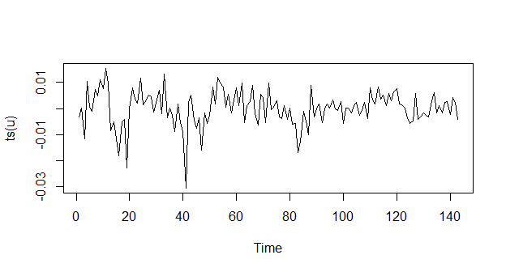

```r
u <- residuals(ecm)
plot(ts(u))
```

```r
aux <- acf2(u)
```

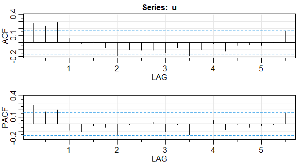

On voit que c’est bien la cas, on rajoute alors des lag pour résoudre le problème.

```r
ecmm <- dynlm(diff(log(cons))~L(spread,1)
               + L(diff(log(cons)),1:3)+L(diff(log(inc)),1:3))

xtable(ecmm) %>%
  kable(digits=2) %>%
  kable_styling()
```

|  | Estimate | Std. Error | t value | Pr(>\|t\|) |
| --- | --- | --- | --- | --- |
| (Intercept) | -0.12 | 0.08 | -1.48 | 0.14 |
| L(spread, 1) | -0.09 | 0.06 | -1.51 | 0.13 |
| L(diff(log(cons)), 1:3)1 | 0.17 | 0.10 | 1.71 | 0.09 |
| L(diff(log(cons)), 1:3)2 | 0.13 | 0.10 | 1.28 | 0.20 |
| L(diff(log(cons)), 1:3)3 | 0.25 | 0.10 | 2.56 | 0.01 |
| L(diff(log(inc)), 1:3)1 | 0.06 | 0.08 | 0.71 | 0.48 |
| L(diff(log(inc)), 1:3)2 | -0.02 | 0.08 | -0.29 | 0.77 |
| L(diff(log(inc)), 1:3)3 | -0.03 | 0.08 | -0.39 | 0.70 |

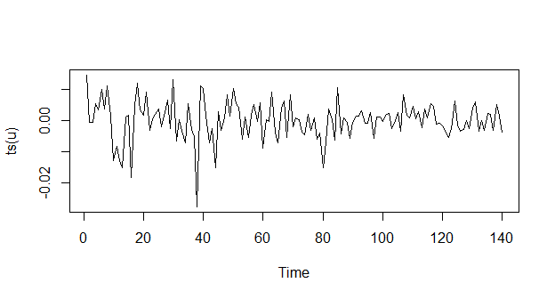

```r
u <- residuals(ecmm)
plot(ts(u))
```

```r
aux <- acf2(u)
```

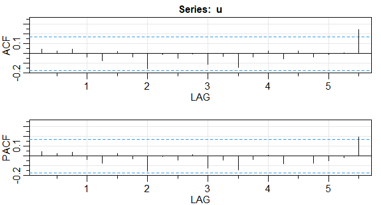

On voit que l’on a bien éliminé presque l’intégralité de la significativité des résidus, hormis à un lag très lointain.

En outre, on peut voir que le coefficient du spread n’est pas significatif, autrement dit le consommation ne s’adapte pas sur le long terme.

# Exercice 2 : Pour les modèles ECM :

L’intérêt du modèle ECM est double:

- Estimer un modèle ECM sera une manière de vérifier la relation de long terme et les vitesses d’ajustement.
- Le modèle ECM fait intervenir uniquement des variables stationnaires, donc les estimateurs ont les propriétés habituelles.

On commence par notre modélisation

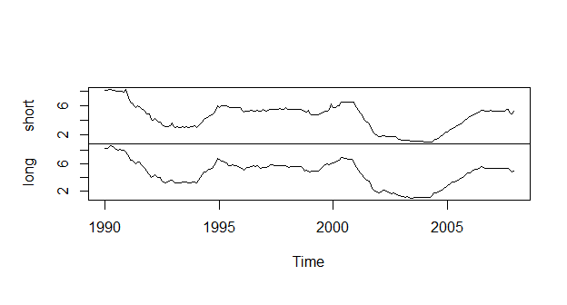

```r
library(Quandl)
Quandl.api_key("2EH6n_vqDHFij5B1d-eH")
short <- Quandl("FED/RILSPDEPM01_N_M",
                start_date="1990-01-31",
                end_date="2007-12-31",
                type="ts")
long <- Quandl("FED/RILSPDEPM06_N_M",
               start_date="1990-01-31",
               end_date="2007-12-31",
               type="ts")
plot.ts(ts.intersect(short,long),main="")
```

```r
dynamicols <- cointRegD(short, long,
                         info.crit = "BIC",
                         deter = rep(1, length(short)))
print(dynamicols)
```

```
##
## ### D-OLS model ###
##
## Model:       long ~ rep(1, length(short)) + short
##
## Parameters:  Kernel = "ba"  //  Bandwidth = 15.02781 ("Andrews")
##
##      Leads = 2 / Lags = 1 / kmax = k4 / IC = BIC
##
## Coefficients:
##         Estimate  Std.Err t value Pr(|t|>0)
## deter   0.157418 0.063430  2.4818   0.01384 *
## x.coint 1.006365 0.013361 75.3227   < 2e-16 ***
## ---
## Signif. codes:  0 '***' 0.001 '**' 0.01 '*' 0.05 '.' 0.1 ' ' 1
```

On voit que notre coefficient est significatif et est presque égale à 1, on peut alors écrire :

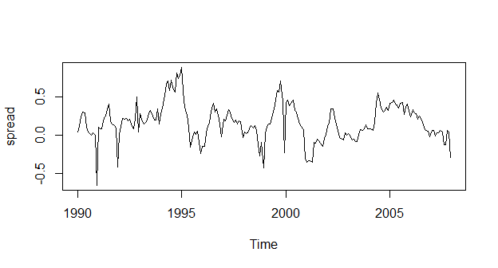

```r
spread <- long - 1*short
plot(spread)
```

```r
aux <- acf2(spread)
```

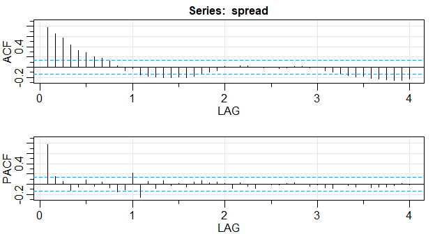

On estime ensuite un modèle ECM, **sachant que s’il y a de l’autocorrélation dans les termes d’erreurs, il nous faudra alors introduire des variables différenciées retardées dans l’ECM.**

```r
ecm <- dynlm(diff(short)~L(spread,1) )
xtable(ecm) %>%
  kable(digits=2) %>%
  kable_styling()
```

|  | Estimate | Std. Error | t value | Pr(>\|t\|) |
| --- | --- | --- | --- | --- |
| (Intercept) | -0.12 | 0.01 | -8.16 | 0 |
| L(spread, 1) | 0.63 | 0.05 | 12.39 | 0 |

On voit dans les figure ACF et PACF ci-dessous qu’il reste de la corrélation dans les résidus.

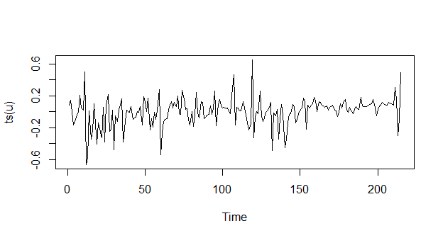

```r
u <- residuals(ecm)
plot(ts(u))
```

```r
aux <- acf2(u)
```

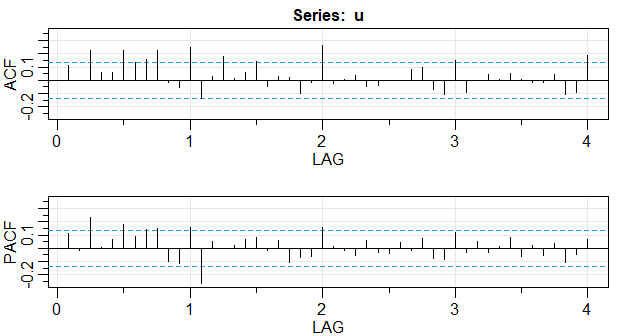

On tente donc de transformer nos résidus en bruit blanc en ajoutant des retards.

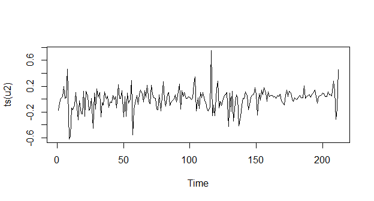

```r
ecmarshort <- dynlm(diff(short)~L(spread,1)
+ L(diff(short),1:3)+L(diff(long),1:3))
u2 <- residuals(ecmarshort)
plot(ts(u2))
```

```r
aux <- acf2(u2)
```

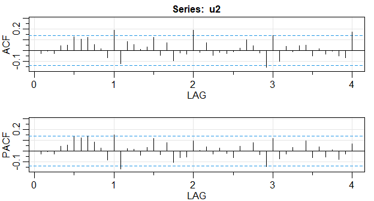

On voit que cela a fortement réduit le nombre de lags significtifs mais également l’ampleur de cette significativité.

On tente une nouvelle fois de rajouter des lags pour obtenir des résidus ‘bruit blanc’.

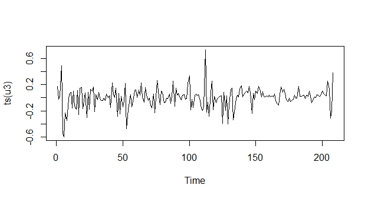

```r
ecmarshort2 <- dynlm(diff(short)~L(spread,1)
+ L(diff(short),1:7)+L(diff(long),1:7))
u3 <- residuals(ecmarshort2)
plot(ts(u3))
```

```r
aux <- acf2(u3)
```

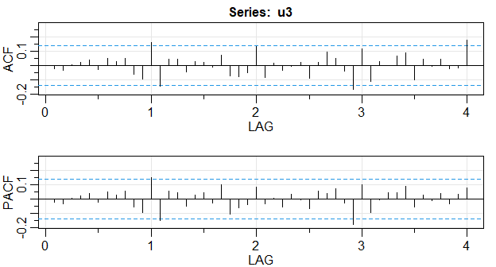

On obtient alors presque uniquement des lag non-significatifs et des lags significatifs qui le sont d’une très faible ampleur.

On ré-itère l’opération pour un second modèle :

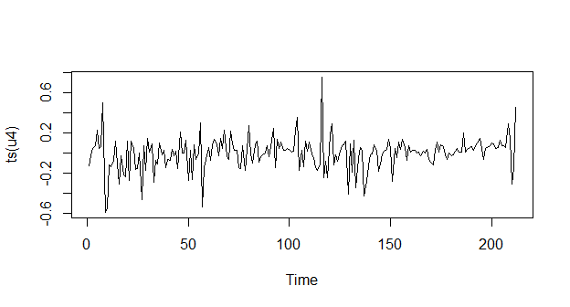

```r
ecmarshort3 <- dynlm(diff(short)~L(long,1) + L(short,1)
+ L(diff(short),1:3)+L(diff(long),1:3))
u4 <- residuals(ecmarshort3)
plot(ts(u4))
```

```r
aux <- acf2(u4)
```

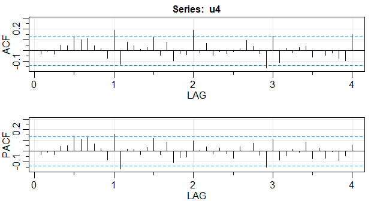

On voit que, comme dans le cas précédent, il y encore de la corrélation dans les résidus, on implémente alors un modèle avec plus de lag

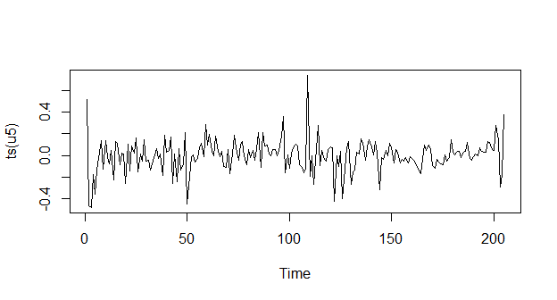

```r
ecmarshort4 <- dynlm(diff(short)~L(long,1) + L(short,1)
+ L(diff(short),1:10)+L(diff(long),1:10))
u5 <- residuals(ecmarshort4)
plot(ts(u5))
```

```r
aux <- acf2(u5)
```

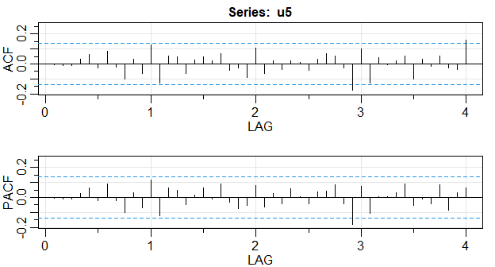

En implémentant 10 lags dans le modèle, on élimine alors presque entièrement la significativité des lags qui l’étaient précedement.

Enfin, on réitère cette procédure de vérification pour un dernier modèle :

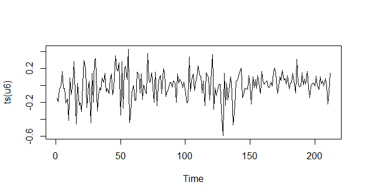

```r
ecmarlong <- dynlm(diff(long)~L(spread,1)
+ L(diff(short),1:3)+L(diff(long),1:3))
u6 <- residuals(ecmarlong)
plot(ts(u6))
```

```r
aux <- acf2(u6)
```

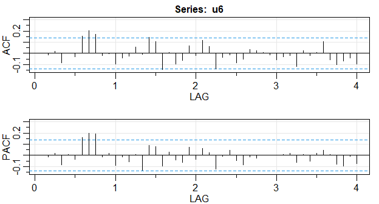

On voit qu’il reste de la significativité pour certains lag au début, mais assez faible. Il semble donc qu’il ne soit pas nécessaire d’ajouter trop de lag à notre modèle pour résoudre le problème.

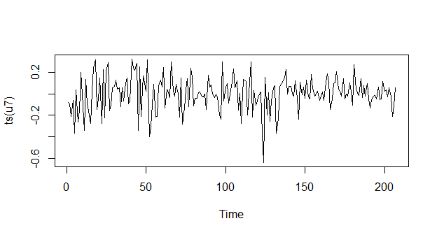

```r
ecmarlong2 <- dynlm(diff(long)~L(spread,1)
+ L(diff(short),1:8)+L(diff(long),1:8))
u7 <- residuals(ecmarlong2)
plot(ts(u7))
```

```r
aux <- acf2(u7)
```

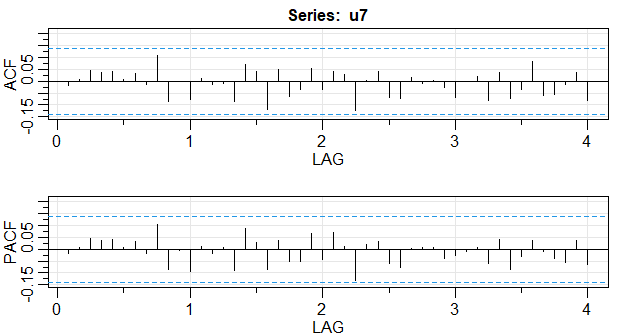

On voit sur les ACF et PACF des résidus de ce modèle que l’ajout de 5 lags a permis de rendre ces derniers ‘bruit blanc’, d’éliminer l’intégralité des corrélation significatives.